# Trabajo final

Indicaciones:

1. Utilizando scipy. stats, crea un programa que modele la probabilidad de obtener un

número específico de éxitos en una serie de lanzamientos de una moneda sin trucos (probabilidad de éxito p = 0. 5). Genera la probabilidad de obtener exactamente 7 caras en 10 lanzamientos

```python
# usamos distribución binomial

from scipy.stats import binom

# Probabilidad de obtener exactamente 7 caras en 10 lanzamientos

binom.pmf(7, 10, 0.5)
```

```
0.11718749999999999
```

Calcula la probabilidad acumulada de obtener 7 o menos caras en 10 lanzamientos

```python
binom.cdf(7, 10, 0.5)
```

```
0.9453125
```

Grafica la distribución binomial completa para los 10 lanzamientos, mostrando la probabilidad de obtener desde 0 hasta 10 caras.

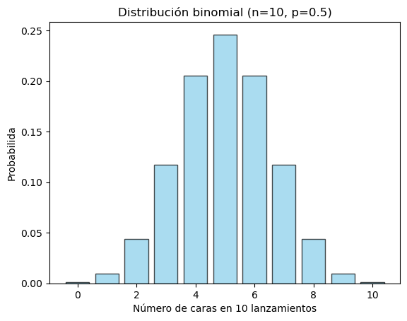

```python
import numpy as np
import matplotlib.pyplot as plt
from scipy.stats import binom

# Definir los valores posibles de caras en 10 lanzamientos
x=np.arange(0, 11)
y=binom.pmf(x, 10, 0.5)

#Graficar la distribución binomial
plt.bar(x, y, color="skyblue", alpha=0.7, edgecolor="black")
plt.xlabel("Número de caras en 10 lanzamientos")
plt.ylabel("Probabilida")
plt.title("Distribución binomial (n=10, p=0.5)")
plt.show()
```

Ahora la moneda tiene mayor probabilidad de caer en cara (probabilidad de éxito p = 0. 8). ¿Cómo cambian los resultados? Vuelve a realizar los ejercicios I, II y III.

```python
# 1. Genera la probabilidad de obtener exactamente 7 caras en 10 lanzamientos
binom.pmf(7, 10, 0.8)
```

```
0.20132659199999978
```

```python
#2 Calcula la probabilidad acumulada de obtener 7 o menos caras en 10 lanzamientos
binom.cdf(7, 10, 0.8)
```

```
0.32220047359999987
```

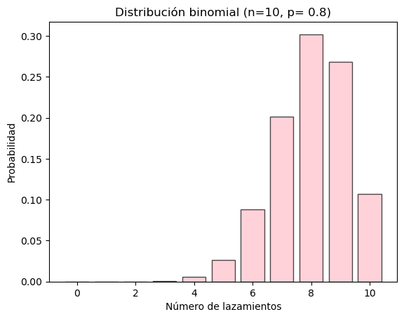

```python
#Grafica la probabilidad
import numpy as np
import matplotlib.pyplot as plt
from scipy.stats import binom

x= np.arange(0, 11)
y=binom.pmf(x, 10, 0.8)

plt.bar(x, y, color="pink", alpha=0.7, edgecolor= "black")
plt.xlabel("Número de lazamientos")
plt.ylabel("Probabilidad")
plt.title("Distribución binomial (n=10, p= 0.8)")
```

Utilizando scipy. stats, realiza un análisis de una distribución normal con una media de 0 y desviación estándar de 1. Genera un conjunto de datos aleatorios con 1000 muestras a partir de esta distribución.

```python
from scipy.stats import norm

norm.rvs(0, 1, size=1000)
```

[output not shown]

[output cut: 195 more lines]

[output not shown]

Calcula y muestra la media, la desviación estándar y la mediana de los datos generados.

```python
import numpy as np

data = norm.rvs(0, 1, size=1000)

# Media
media = np.mean(data)

# Desviación estandar
std = np.std(data)

# Mediana
median = np.median(data)

print("Media:", media)
print("Desviación estándar:", std)
print("Mediana:", median)
```

```
Media: 0.01771682355809338
Desviación estándar: 1.0190264023194002
Mediana: -0.009080405217753003
```

Grafica el histograma de los datos y superpón la curva de la distribución normal teórica.

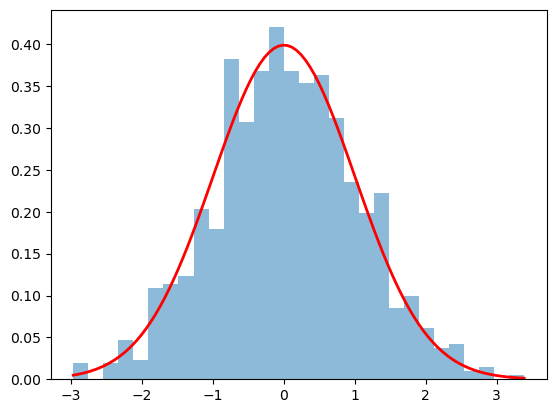

```python
import matplotlib.pyplot as plt
import numpy as np
from scipy.stats import norm

#datos
data = norm.rvs(0, 1, size=1000)
media = np.mean(data)
std = np.std(data)
x = np.linspace(min(data), max(data), 100)
y = norm.pdf(x, 0, 1)

plt.hist(data, density=True, bins=30, alpha=0.5)
plt.plot(x, y, color="red", linewidth=2)
plt.show()
```

# Parte 2

Grupo 4

Realiza 4 gráficos con la base de datos de tu elección. Ojo que cualquiera de las opciones implica realizar alguna limpieza de los datos.

--- Usamos los indicadores de Desarrollo Global ---

# "Evolución de 'Access to electricity (% of population)' en Perú"

```python
import pandas as pd
import matplotlib.pyplot as plt

# Cargar los archivos con la codificación correcta
metadata_df = pd.read_csv('51f7ab6a-24ed-4a06-9f5d-04873f1673fd_Series - Metadata-1 (1).csv', encoding='latin-1')
data_df = pd.read_csv('51f7ab6a-24ed-4a06-9f5d-04873f1673fd_Data-1 (1).csv', encoding='latin-1')
```

```python
# Combinar las bases de datos usando merge
combined_df = data_df.merge(metadata_df, left_on='Series Code', right_on='Country Code', how='left')

combined_df
```

|  | Country Name_x | Country Code_x | Series Name_x | Series Code_x | 1960 [YR1960]_x | 1961 [YR1961]_x | 1962 [YR1962]_x | 1963 [YR1963]_x | 1964 [YR1964]_x | 1965 [YR1965]_x | ... | 2013 [YR2013]_y | 2014 [YR2014]_y | 2015 [YR2015]_y | 2016 [YR2016]_y | 2017 [YR2017]_y | 2018 [YR2018]_y | 2019 [YR2019]_y | 2020 [YR2020]_y | 2021 [YR2021]_y | 2022 [YR2022]_y |
| --- | --- | --- | --- | --- | --- | --- | --- | --- | --- | --- | --- | --- | --- | --- | --- | --- | --- | --- | --- | --- | --- |
| 0 | Afghanistan | AFG | Access to electricity (% of population) | EG.ELC.ACCS.ZS | .. | .. | .. | .. | .. | .. | ... | NaN | NaN | NaN | NaN | NaN | NaN | NaN | NaN | NaN | NaN |
| 1 | Afghanistan | AFG | Access to electricity, rural (% of rural popul... | EG.ELC.ACCS.RU.ZS | .. | .. | .. | .. | .. | .. | ... | NaN | NaN | NaN | NaN | NaN | NaN | NaN | NaN | NaN | NaN |
| 2 | Afghanistan | AFG | CO2 emissions (metric tons per capita) | EN.ATM.CO2E.PC | .. | .. | .. | .. | .. | .. | ... | NaN | NaN | NaN | NaN | NaN | NaN | NaN | NaN | NaN | NaN |
| 3 | Afghanistan | AFG | GDP growth (annual %) | NY.GDP.MKTP.KD.ZG | .. | .. | .. | .. | .. | .. | ... | NaN | NaN | NaN | NaN | NaN | NaN | NaN | NaN | NaN | NaN |
| 4 | Afghanistan | AFG | Hospital beds (per 1,000 people) | SH.MED.BEDS.ZS | 0.170626997947693 | .. | .. | .. | .. | .. | ... | NaN | NaN | NaN | NaN | NaN | NaN | NaN | NaN | NaN | NaN |
| ... | ... | ... | ... | ... | ... | ... | ... | ... | ... | ... | ... | ... | ... | ... | ... | ... | ... | ... | ... | ... | ... |
| 1616 | Last Updated: 12/18/2023 | NaN | NaN | NaN | NaN | NaN | NaN | NaN | NaN | NaN | ... | NaN | NaN | NaN | NaN | NaN | NaN | NaN | NaN | NaN | NaN |
| 1617 | Last Updated: 12/18/2023 | NaN | NaN | NaN | NaN | NaN | NaN | NaN | NaN | NaN | ... | NaN | NaN | NaN | NaN | NaN | NaN | NaN | NaN | NaN | NaN |
| 1618 | Last Updated: 12/18/2023 | NaN | NaN | NaN | NaN | NaN | NaN | NaN | NaN | NaN | ... | NaN | NaN | NaN | NaN | NaN | NaN | NaN | NaN | NaN | NaN |
| 1619 | Last Updated: 12/18/2023 | NaN | NaN | NaN | NaN | NaN | NaN | NaN | NaN | NaN | ... | NaN | NaN | NaN | NaN | NaN | NaN | NaN | NaN | NaN | NaN |
| 1620 | Last Updated: 12/18/2023 | NaN | NaN | NaN | NaN | NaN | NaN | NaN | NaN | NaN | ... | NaN | NaN | NaN | NaN | NaN | NaN | NaN | NaN | NaN | NaN |

1621 rows × 134 columns

```python
print(combined_df.columns)
```

```
Index(['Country Name_x', 'Country Code_x', 'Series Name_x', 'Series Code_x',
       '1960 [YR1960]_x', '1961 [YR1961]_x', '1962 [YR1962]_x',
       '1963 [YR1963]_x', '1964 [YR1964]_x', '1965 [YR1965]_x',
       ...
       '2013 [YR2013]_y', '2014 [YR2014]_y', '2015 [YR2015]_y',
       '2016 [YR2016]_y', '2017 [YR2017]_y', '2018 [YR2018]_y',
       '2019 [YR2019]_y', '2020 [YR2020]_y', '2021 [YR2021]_y',
       '2022 [YR2022]_y'],
      dtype='object', length=134)
```

```python
combined_df.drop(columns=['Country Code_x'], inplace=True, errors='ignore')
combined_df
```

|  | Country Name_x | Series Name_x | Series Code_x | 1960 [YR1960]_x | 1961 [YR1961]_x | 1962 [YR1962]_x | 1963 [YR1963]_x | 1964 [YR1964]_x | 1965 [YR1965]_x | 1966 [YR1966]_x | ... | 2013 [YR2013]_y | 2014 [YR2014]_y | 2015 [YR2015]_y | 2016 [YR2016]_y | 2017 [YR2017]_y | 2018 [YR2018]_y | 2019 [YR2019]_y | 2020 [YR2020]_y | 2021 [YR2021]_y | 2022 [YR2022]_y |
| --- | --- | --- | --- | --- | --- | --- | --- | --- | --- | --- | --- | --- | --- | --- | --- | --- | --- | --- | --- | --- | --- |
| 0 | Afghanistan | Access to electricity (% of population) | EG.ELC.ACCS.ZS | .. | .. | .. | .. | .. | .. | .. | ... | NaN | NaN | NaN | NaN | NaN | NaN | NaN | NaN | NaN | NaN |
| 1 | Afghanistan | Access to electricity, rural (% of rural popul... | EG.ELC.ACCS.RU.ZS | .. | .. | .. | .. | .. | .. | .. | ... | NaN | NaN | NaN | NaN | NaN | NaN | NaN | NaN | NaN | NaN |
| 2 | Afghanistan | CO2 emissions (metric tons per capita) | EN.ATM.CO2E.PC | .. | .. | .. | .. | .. | .. | .. | ... | NaN | NaN | NaN | NaN | NaN | NaN | NaN | NaN | NaN | NaN |
| 3 | Afghanistan | GDP growth (annual %) | NY.GDP.MKTP.KD.ZG | .. | .. | .. | .. | .. | .. | .. | ... | NaN | NaN | NaN | NaN | NaN | NaN | NaN | NaN | NaN | NaN |
| 4 | Afghanistan | Hospital beds (per 1,000 people) | SH.MED.BEDS.ZS | 0.170626997947693 | .. | .. | .. | .. | .. | .. | ... | NaN | NaN | NaN | NaN | NaN | NaN | NaN | NaN | NaN | NaN |
| ... | ... | ... | ... | ... | ... | ... | ... | ... | ... | ... | ... | ... | ... | ... | ... | ... | ... | ... | ... | ... | ... |
| 1616 | Last Updated: 12/18/2023 | NaN | NaN | NaN | NaN | NaN | NaN | NaN | NaN | NaN | ... | NaN | NaN | NaN | NaN | NaN | NaN | NaN | NaN | NaN | NaN |
| 1617 | Last Updated: 12/18/2023 | NaN | NaN | NaN | NaN | NaN | NaN | NaN | NaN | NaN | ... | NaN | NaN | NaN | NaN | NaN | NaN | NaN | NaN | NaN | NaN |
| 1618 | Last Updated: 12/18/2023 | NaN | NaN | NaN | NaN | NaN | NaN | NaN | NaN | NaN | ... | NaN | NaN | NaN | NaN | NaN | NaN | NaN | NaN | NaN | NaN |
| 1619 | Last Updated: 12/18/2023 | NaN | NaN | NaN | NaN | NaN | NaN | NaN | NaN | NaN | ... | NaN | NaN | NaN | NaN | NaN | NaN | NaN | NaN | NaN | NaN |
| 1620 | Last Updated: 12/18/2023 | NaN | NaN | NaN | NaN | NaN | NaN | NaN | NaN | NaN | ... | NaN | NaN | NaN | NaN | NaN | NaN | NaN | NaN | NaN | NaN |

1621 rows × 133 columns

```python
  combined_df =combined_df.rename(columns={
        "Country Name_x": "Country Name",
        "Series Name_x": "Series Name"
    })

combined_df
```

|  | Country Name | Series Name | Series Code_x | 1960 [YR1960]_x | 1961 [YR1961]_x | 1962 [YR1962]_x | 1963 [YR1963]_x | 1964 [YR1964]_x | 1965 [YR1965]_x | 1966 [YR1966]_x | ... | 2013 [YR2013]_y | 2014 [YR2014]_y | 2015 [YR2015]_y | 2016 [YR2016]_y | 2017 [YR2017]_y | 2018 [YR2018]_y | 2019 [YR2019]_y | 2020 [YR2020]_y | 2021 [YR2021]_y | 2022 [YR2022]_y |
| --- | --- | --- | --- | --- | --- | --- | --- | --- | --- | --- | --- | --- | --- | --- | --- | --- | --- | --- | --- | --- | --- |
| 0 | Afghanistan | Access to electricity (% of population) | EG.ELC.ACCS.ZS | .. | .. | .. | .. | .. | .. | .. | ... | NaN | NaN | NaN | NaN | NaN | NaN | NaN | NaN | NaN | NaN |
| 1 | Afghanistan | Access to electricity, rural (% of rural popul... | EG.ELC.ACCS.RU.ZS | .. | .. | .. | .. | .. | .. | .. | ... | NaN | NaN | NaN | NaN | NaN | NaN | NaN | NaN | NaN | NaN |
| 2 | Afghanistan | CO2 emissions (metric tons per capita) | EN.ATM.CO2E.PC | .. | .. | .. | .. | .. | .. | .. | ... | NaN | NaN | NaN | NaN | NaN | NaN | NaN | NaN | NaN | NaN |
| 3 | Afghanistan | GDP growth (annual %) | NY.GDP.MKTP.KD.ZG | .. | .. | .. | .. | .. | .. | .. | ... | NaN | NaN | NaN | NaN | NaN | NaN | NaN | NaN | NaN | NaN |
| 4 | Afghanistan | Hospital beds (per 1,000 people) | SH.MED.BEDS.ZS | 0.170626997947693 | .. | .. | .. | .. | .. | .. | ... | NaN | NaN | NaN | NaN | NaN | NaN | NaN | NaN | NaN | NaN |
| ... | ... | ... | ... | ... | ... | ... | ... | ... | ... | ... | ... | ... | ... | ... | ... | ... | ... | ... | ... | ... | ... |
| 1616 | Last Updated: 12/18/2023 | NaN | NaN | NaN | NaN | NaN | NaN | NaN | NaN | NaN | ... | NaN | NaN | NaN | NaN | NaN | NaN | NaN | NaN | NaN | NaN |
| 1617 | Last Updated: 12/18/2023 | NaN | NaN | NaN | NaN | NaN | NaN | NaN | NaN | NaN | ... | NaN | NaN | NaN | NaN | NaN | NaN | NaN | NaN | NaN | NaN |
| 1618 | Last Updated: 12/18/2023 | NaN | NaN | NaN | NaN | NaN | NaN | NaN | NaN | NaN | ... | NaN | NaN | NaN | NaN | NaN | NaN | NaN | NaN | NaN | NaN |
| 1619 | Last Updated: 12/18/2023 | NaN | NaN | NaN | NaN | NaN | NaN | NaN | NaN | NaN | ... | NaN | NaN | NaN | NaN | NaN | NaN | NaN | NaN | NaN | NaN |
| 1620 | Last Updated: 12/18/2023 | NaN | NaN | NaN | NaN | NaN | NaN | NaN | NaN | NaN | ... | NaN | NaN | NaN | NaN | NaN | NaN | NaN | NaN | NaN | NaN |

1621 rows × 133 columns

```python
filtered_combined_df = combined_df[(combined_df["Country Name"] == "Peru") & (combined_df["Series Name"] == "Access to electricity (% of population)")]
filtered_combined_df
```

|  | Country Name | Series Name | Series Code_x | 1960 [YR1960]_x | 1961 [YR1961]_x | 1962 [YR1962]_x | 1963 [YR1963]_x | 1964 [YR1964]_x | 1965 [YR1965]_x | 1966 [YR1966]_x | ... | 2013 [YR2013]_y | 2014 [YR2014]_y | 2015 [YR2015]_y | 2016 [YR2016]_y | 2017 [YR2017]_y | 2018 [YR2018]_y | 2019 [YR2019]_y | 2020 [YR2020]_y | 2021 [YR2021]_y | 2022 [YR2022]_y |
| --- | --- | --- | --- | --- | --- | --- | --- | --- | --- | --- | --- | --- | --- | --- | --- | --- | --- | --- | --- | --- | --- |
| 924 | Peru | Access to electricity (% of population) | EG.ELC.ACCS.ZS | .. | .. | .. | .. | .. | .. | .. | ... | NaN | NaN | NaN | NaN | NaN | NaN | NaN | NaN | NaN | NaN |

1 rows × 133 columns

```python
  # Extraer columnas que contienen 'YR' usando indexación condicional
yr_columns = filtered_combined_df.loc[:, filtered_combined_df.columns.str.contains("YR")]

# Limpiar datos eliminando valores vacíos
filtered_data = yr_columns.replace(["..", None, "NaN", float("nan")], pd.NA).dropna(axis=1)

# Extraer años y valores
years = filtered_data.columns.str.split("[").str[0].str.strip().tolist()
values = filtered_data.iloc[0].astype(float).tolist()
```

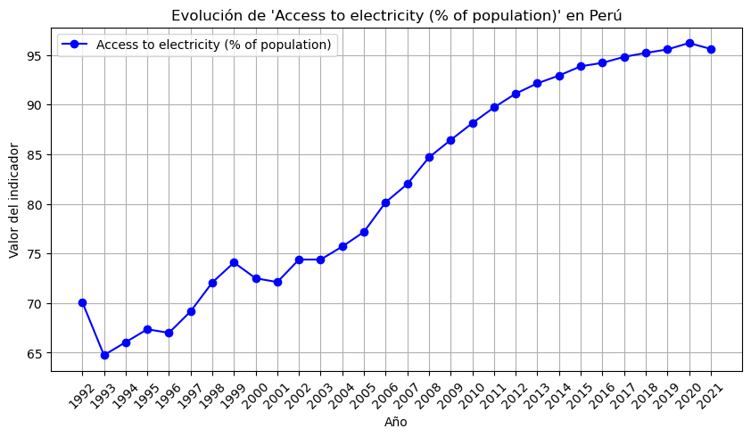

```python
# Graficar la evolución del indicador
plt.figure(figsize=(10, 5))
plt.plot(years, values, marker="o", linestyle="-", color="b", label="Access to electricity (% of population)")

plt.xlabel("Año")
plt.ylabel("Valor del indicador")
plt.title("Evolución de 'Access to electricity (% of population)' en Perú")
plt.xticks(rotation=45)
plt.legend()
plt.grid(True)
plt.show()
```

# 'Acceso a electricidad en Perú, según ubicación'

```python
#----- grafico comparando access to electricity vs access to electricity rural, mostrando el gap a traves del tiempo en peru
# seleccionando data de peru
peru_df= data_df[(data_df['Country Name'] == 'Peru')]
peru_df = peru_df.reset_index(drop=True)

# seleccionando variables de interes
peru_electr = peru_df.iloc[[0,1]]
peru_electr = peru_electr.T

peru_electr = peru_electr.iloc[4:]
#columnas:
#Access to electricity (% of population)
#Access to electricity, rural (% of rural population

# lidiando con datos faltantes
import numpy as np
peru_electr.replace("..", np.nan, inplace=True)
peru_electr = peru_electr.dropna()
peru_electr.head(10)

#arreglando nombres de columnas
peru_electr.index = peru_electr.index.str.extract(r'(\d{4})')[0]
peru_electr_df = peru_electr.rename(columns = {peru_electr.columns[0]: 'total',
                                                peru_electr.columns[1]: 'rural'})

peru_electr_df['total'] = pd.to_numeric(peru_electr_df['total'])
peru_electr_df['rural'] = pd.to_numeric(peru_electr_df['rural'])

peru_electr_df.info()
```

```
<class 'pandas.core.frame.DataFrame'>
Index: 30 entries, 1992 to 2021
Data columns (total 2 columns):
 #   Column  Non-Null Count  Dtype
---  ------  --------------  -----
 0   total   30 non-null     float64
 1   rural   30 non-null     float64
dtypes: float64(2)
memory usage: 720.0+ bytes
```

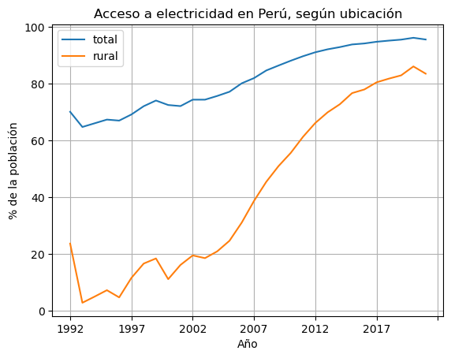

```python
import matplotlib.pyplot as plt

peru_electr_df.plot()
plt.title('Acceso a electricidad en Perú, según ubicación',fontdict={'fontsize':12})
plt.xlabel('Año')
plt.ylabel('% de la población')
plt.grid(True)
plt.show()
```

# % de poblacion con electricidad en seis paises de Suramérica

```python
data1=data_df[data_df['Series Code']=='EG.ELC.ACCS.ZS']
data2=data1.reset_index(drop=True)
data2=data2.iloc[[23,26,40,42,57,154],:]
data3=data2.reset_index(drop=True)
data3
```

|  | Country Name | Country Code | Series Name | Series Code | 1960 [YR1960] | 1961 [YR1961] | 1962 [YR1962] | 1963 [YR1963] | 1964 [YR1964] | 1965 [YR1965] | ... | 2013 [YR2013] | 2014 [YR2014] | 2015 [YR2015] | 2016 [YR2016] | 2017 [YR2017] | 2018 [YR2018] | 2019 [YR2019] | 2020 [YR2020] | 2021 [YR2021] | 2022 [YR2022] |
| --- | --- | --- | --- | --- | --- | --- | --- | --- | --- | --- | --- | --- | --- | --- | --- | --- | --- | --- | --- | --- | --- |
| 0 | Bolivia | BOL | Access to electricity (% of population) | EG.ELC.ACCS.ZS | .. | .. | .. | .. | .. | .. | ... | 89.505686 | 90.038729 | 91.522822 | 91.8 | 91.8 | 92.8 | 95.08 | 97.2218170166016 | 98.5562286376953 | .. |
| 1 | Brazil | BRA | Access to electricity (% of population) | EG.ELC.ACCS.ZS | .. | .. | .. | .. | .. | .. | ... | 99.575151 | 99.650247 | 99.710902 | 99.7 | 99.8 | 99.7 | 99.8 | 99.7027130126953 | 99.4621200561523 | .. |
| 2 | Chile | CHL | Access to electricity (% of population) | EG.ELC.ACCS.ZS | .. | .. | .. | .. | .. | .. | ... | 99.6 | 100 | 99.714844 | 100 | 99.7 | 100 | 100 | 100 | 100 | .. |
| 3 | Colombia | COL | Access to electricity (% of population) | EG.ELC.ACCS.ZS | .. | .. | .. | .. | .. | .. | ... | 97.779418 | 97.790938 | 98.186898 | 98.4 | 98.5 | 98.5 | 99.4442596435547 | 99.7217559814453 | 99.9991073608398 | .. |
| 4 | Ecuador | ECU | Access to electricity (% of population) | EG.ELC.ACCS.ZS | .. | .. | .. | .. | .. | .. | ... | 98.034674 | 98.976067 | 98.825883 | 98.7 | 99.2 | 98.7 | 99.09 | 98.85 | 100 | .. |
| 5 | Peru | PER | Access to electricity (% of population) | EG.ELC.ACCS.ZS | .. | .. | .. | .. | .. | .. | ... | 92.135365 | 92.919989 | 93.852179 | 94.2 | 94.8 | 95.2 | 95.551360223182 | 96.2 | 95.6 | .. |

6 rows × 67 columns

```python
import numpy as np
data3.set_index('Country Name', inplace=True)
data3=data3.T
data3
data4=data3.iloc[3:]
data4
```

| Country Name | Bolivia | Brazil | Chile | Colombia | Ecuador | Peru |
| --- | --- | --- | --- | --- | --- | --- |
| 1960 [YR1960] | .. | .. | .. | .. | .. | .. |
| 1961 [YR1961] | .. | .. | .. | .. | .. | .. |
| 1962 [YR1962] | .. | .. | .. | .. | .. | .. |
| 1963 [YR1963] | .. | .. | .. | .. | .. | .. |
| 1964 [YR1964] | .. | .. | .. | .. | .. | .. |
| ... | ... | ... | ... | ... | ... | ... |
| 2018 [YR2018] | 92.8 | 99.7 | 100 | 98.5 | 98.7 | 95.2 |
| 2019 [YR2019] | 95.08 | 99.8 | 100 | 99.4442596435547 | 99.09 | 95.551360223182 |
| 2020 [YR2020] | 97.2218170166016 | 99.7027130126953 | 100 | 99.7217559814453 | 98.85 | 96.2 |
| 2021 [YR2021] | 98.5562286376953 | 99.4621200561523 | 100 | 99.9991073608398 | 100 | 95.6 |
| 2022 [YR2022] | .. | .. | .. | .. | .. | .. |

63 rows × 6 columns

```python
data4.replace('..',np.nan,inplace=True)
data4=data4.dropna()
data4
```

| Country Name | Bolivia | Brazil | Chile | Colombia | Ecuador | Peru |
| --- | --- | --- | --- | --- | --- | --- |
| 1995 [YR1995] | 64.0915298461914 | 91.728598 | 95.760383605957 | 91.2 | 89.830167 | 67.3548355102539 |
| 1996 [YR1996] | 71 | 92.867095 | 95.617315 | 93.3031005859375 | 92.0513763427734 | 67 |
| 1997 [YR1997] | 67.330431 | 93.354139 | 96.2361679077148 | 93.5889129638672 | 92.429817199707 | 69.16024 |
| 1998 [YR1998] | 71.2 | 94.193812 | 97.241124 | 93.8706436157227 | 92.726642 | 72.072063 |
| 1999 [YR1999] | 70.929888 | 94.76296 | 96.6955490112305 | 94.1475296020508 | 93.071434 | 74.078523 |
| 2000 [YR2000] | 69.963045 | 94.4314117431641 | 97.938687 | 95.2 | 93.6975250244141 | 72.496495 |
| 2001 [YR2001] | 69.258539 | 96.016528 | 97.1343612670898 | 98.47 | 93.9700241088867 | 72.113111 |
| 2002 [YR2002] | 63.996855 | 96.652996 | 97.2666854858398 | 94.8810424804688 | 94.2339706420898 | 74.382688 |
| 2003 [YR2003] | 72.3 | 96.980098 | 98.782325 | 95.0771865844727 | 94.973044 | 74.380966 |
| 2004 [YR2004] | 75.865852355957 | 96.765107 | 97.5337295532227 | 95.2788009643555 | 94.7642669677734 | 75.692357 |
| 2005 [YR2005] | 68.288209 | 97.093513 | 97.6824645996094 | 96.8 | 95.83265 | 77.173645 |
| 2006 [YR2006] | 76.211281 | 97.594314 | 99.368108 | 95.7262268066406 | 96.315259 | 80.157275 |
| 2007 [YR2007] | 80.156567 | 98.125382 | 98.0392684936523 | 95.9804077148438 | 96.812618 | 81.988131 |
| 2008 [YR2008] | 84.674991 | 98.526625 | 98.2453155517578 | 96.806763 | 97.206576 | 84.678343 |
| 2009 [YR2009] | 86.765597 | 98.856938 | 99.593662 | 96.057229 | 96.470862 | 86.42432 |
| 2010 [YR2010] | 87.9524154663086 | 98.6 | 99.5258941650391 | 96.788995 | 97.462142 | 88.123061 |
| 2011 [YR2011] | 88.335943 | 99.328691 | 99.588193 | 96.6936 | 96.872699 | 89.707491 |
| 2012 [YR2012] | 90.387375 | 99.519494 | 100 | 97.032176 | 97.194929 | 91.099508 |
| 2013 [YR2013] | 89.505686 | 99.575151 | 99.6 | 97.779418 | 98.034674 | 92.135365 |
| 2014 [YR2014] | 90.038729 | 99.650247 | 100 | 97.790938 | 98.976067 | 92.919989 |
| 2015 [YR2015] | 91.522822 | 99.710902 | 99.714844 | 98.186898 | 98.825883 | 93.852179 |
| 2016 [YR2016] | 91.8 | 99.7 | 100 | 98.4 | 98.7 | 94.2 |
| 2017 [YR2017] | 91.8 | 99.8 | 99.7 | 98.5 | 99.2 | 94.8 |
| 2018 [YR2018] | 92.8 | 99.7 | 100 | 98.5 | 98.7 | 95.2 |
| 2019 [YR2019] | 95.08 | 99.8 | 100 | 99.4442596435547 | 99.09 | 95.551360223182 |
| 2020 [YR2020] | 97.2218170166016 | 99.7027130126953 | 100 | 99.7217559814453 | 98.85 | 96.2 |
| 2021 [YR2021] | 98.5562286376953 | 99.4621200561523 | 100 | 99.9991073608398 | 100 | 95.6 |

```python
data4['Bolivia'] = pd.to_numeric(data4['Bolivia'])
data4['Brazil'] = pd.to_numeric(data4['Brazil'])
data4['Chile'] = pd.to_numeric(data4['Chile'])
data4['Colombia'] = pd.to_numeric(data4['Colombia'])
data4['Ecuador'] = pd.to_numeric(data4['Ecuador'])
data4['Peru'] = pd.to_numeric(data4['Peru'])
data4
```

[output not shown]

| Country Name | Bolivia | Brazil | Chile | Colombia | Ecuador | Peru |
| --- | --- | --- | --- | --- | --- | --- |
| 1995 [YR1995] | 64.091530 | 91.728598 | 95.760384 | 91.200000 | 89.830167 | 67.354836 |
| 1996 [YR1996] | 71.000000 | 92.867095 | 95.617315 | 93.303101 | 92.051376 | 67.000000 |
| 1997 [YR1997] | 67.330431 | 93.354139 | 96.236168 | 93.588913 | 92.429817 | 69.160240 |
| 1998 [YR1998] | 71.200000 | 94.193812 | 97.241124 | 93.870644 | 92.726642 | 72.072063 |
| 1999 [YR1999] | 70.929888 | 94.762960 | 96.695549 | 94.147530 | 93.071434 | 74.078523 |
| 2000 [YR2000] | 69.963045 | 94.431412 | 97.938687 | 95.200000 | 93.697525 | 72.496495 |
| 2001 [YR2001] | 69.258539 | 96.016528 | 97.134361 | 98.470000 | 93.970024 | 72.113111 |
| 2002 [YR2002] | 63.996855 | 96.652996 | 97.266685 | 94.881042 | 94.233971 | 74.382688 |
| 2003 [YR2003] | 72.300000 | 96.980098 | 98.782325 | 95.077187 | 94.973044 | 74.380966 |
| 2004 [YR2004] | 75.865852 | 96.765107 | 97.533730 | 95.278801 | 94.764267 | 75.692357 |
| 2005 [YR2005] | 68.288209 | 97.093513 | 97.682465 | 96.800000 | 95.832650 | 77.173645 |
| 2006 [YR2006] | 76.211281 | 97.594314 | 99.368108 | 95.726227 | 96.315259 | 80.157275 |
| 2007 [YR2007] | 80.156567 | 98.125382 | 98.039268 | 95.980408 | 96.812618 | 81.988131 |
| 2008 [YR2008] | 84.674991 | 98.526625 | 98.245316 | 96.806763 | 97.206576 | 84.678343 |
| 2009 [YR2009] | 86.765597 | 98.856938 | 99.593662 | 96.057229 | 96.470862 | 86.424320 |
| 2010 [YR2010] | 87.952415 | 98.600000 | 99.525894 | 96.788995 | 97.462142 | 88.123061 |
| 2011 [YR2011] | 88.335943 | 99.328691 | 99.588193 | 96.693600 | 96.872699 | 89.707491 |
| 2012 [YR2012] | 90.387375 | 99.519494 | 100.000000 | 97.032176 | 97.194929 | 91.099508 |
| 2013 [YR2013] | 89.505686 | 99.575151 | 99.600000 | 97.779418 | 98.034674 | 92.135365 |
| 2014 [YR2014] | 90.038729 | 99.650247 | 100.000000 | 97.790938 | 98.976067 | 92.919989 |
| 2015 [YR2015] | 91.522822 | 99.710902 | 99.714844 | 98.186898 | 98.825883 | 93.852179 |
| 2016 [YR2016] | 91.800000 | 99.700000 | 100.000000 | 98.400000 | 98.700000 | 94.200000 |
| 2017 [YR2017] | 91.800000 | 99.800000 | 99.700000 | 98.500000 | 99.200000 | 94.800000 |
| 2018 [YR2018] | 92.800000 | 99.700000 | 100.000000 | 98.500000 | 98.700000 | 95.200000 |
| 2019 [YR2019] | 95.080000 | 99.800000 | 100.000000 | 99.444260 | 99.090000 | 95.551360 |
| 2020 [YR2020] | 97.221817 | 99.702713 | 100.000000 | 99.721756 | 98.850000 | 96.200000 |
| 2021 [YR2021] | 98.556229 | 99.462120 | 100.000000 | 99.999107 | 100.000000 | 95.600000 |

```python
data4.index = data4.index.str.extract(r'(\d{4})')[0]
data4
```

| Country Name 0 | Bolivia | Brazil | Chile | Colombia | Ecuador | Peru |
| --- | --- | --- | --- | --- | --- | --- |
| 1995 | 64.091530 | 91.728598 | 95.760384 | 91.200000 | 89.830167 | 67.354836 |
| 1996 | 71.000000 | 92.867095 | 95.617315 | 93.303101 | 92.051376 | 67.000000 |
| 1997 | 67.330431 | 93.354139 | 96.236168 | 93.588913 | 92.429817 | 69.160240 |
| 1998 | 71.200000 | 94.193812 | 97.241124 | 93.870644 | 92.726642 | 72.072063 |
| 1999 | 70.929888 | 94.762960 | 96.695549 | 94.147530 | 93.071434 | 74.078523 |
| 2000 | 69.963045 | 94.431412 | 97.938687 | 95.200000 | 93.697525 | 72.496495 |
| 2001 | 69.258539 | 96.016528 | 97.134361 | 98.470000 | 93.970024 | 72.113111 |
| 2002 | 63.996855 | 96.652996 | 97.266685 | 94.881042 | 94.233971 | 74.382688 |
| 2003 | 72.300000 | 96.980098 | 98.782325 | 95.077187 | 94.973044 | 74.380966 |
| 2004 | 75.865852 | 96.765107 | 97.533730 | 95.278801 | 94.764267 | 75.692357 |
| 2005 | 68.288209 | 97.093513 | 97.682465 | 96.800000 | 95.832650 | 77.173645 |
| 2006 | 76.211281 | 97.594314 | 99.368108 | 95.726227 | 96.315259 | 80.157275 |
| 2007 | 80.156567 | 98.125382 | 98.039268 | 95.980408 | 96.812618 | 81.988131 |
| 2008 | 84.674991 | 98.526625 | 98.245316 | 96.806763 | 97.206576 | 84.678343 |
| 2009 | 86.765597 | 98.856938 | 99.593662 | 96.057229 | 96.470862 | 86.424320 |
| 2010 | 87.952415 | 98.600000 | 99.525894 | 96.788995 | 97.462142 | 88.123061 |
| 2011 | 88.335943 | 99.328691 | 99.588193 | 96.693600 | 96.872699 | 89.707491 |
| 2012 | 90.387375 | 99.519494 | 100.000000 | 97.032176 | 97.194929 | 91.099508 |
| 2013 | 89.505686 | 99.575151 | 99.600000 | 97.779418 | 98.034674 | 92.135365 |
| 2014 | 90.038729 | 99.650247 | 100.000000 | 97.790938 | 98.976067 | 92.919989 |
| 2015 | 91.522822 | 99.710902 | 99.714844 | 98.186898 | 98.825883 | 93.852179 |
| 2016 | 91.800000 | 99.700000 | 100.000000 | 98.400000 | 98.700000 | 94.200000 |
| 2017 | 91.800000 | 99.800000 | 99.700000 | 98.500000 | 99.200000 | 94.800000 |
| 2018 | 92.800000 | 99.700000 | 100.000000 | 98.500000 | 98.700000 | 95.200000 |
| 2019 | 95.080000 | 99.800000 | 100.000000 | 99.444260 | 99.090000 | 95.551360 |
| 2020 | 97.221817 | 99.702713 | 100.000000 | 99.721756 | 98.850000 | 96.200000 |
| 2021 | 98.556229 | 99.462120 | 100.000000 | 99.999107 | 100.000000 | 95.600000 |

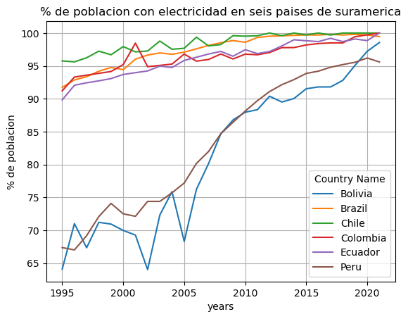

```python
import matplotlib.pyplot as plt
data4.plot()
plt.title('% de poblacion con electricidad en seis paises de suramerica')
plt.xlabel('years')
plt.ylabel('% de poblacion')
plt.grid(True)
plt.show()
```

# Evolución GDP Albania

```python
series = data_df.drop(data_df[data_df["Country Code"] != "ALB"].index)
series
```

|  | Country Name | Country Code | Series Name | Series Code | 1960 [YR1960] | 1961 [YR1961] | 1962 [YR1962] | 1963 [YR1963] | 1964 [YR1964] | 1965 [YR1965] | ... | 2013 [YR2013] | 2014 [YR2014] | 2015 [YR2015] | 2016 [YR2016] | 2017 [YR2017] | 2018 [YR2018] | 2019 [YR2019] | 2020 [YR2020] | 2021 [YR2021] | 2022 [YR2022] |
| --- | --- | --- | --- | --- | --- | --- | --- | --- | --- | --- | --- | --- | --- | --- | --- | --- | --- | --- | --- | --- | --- |
| 6 | Albania | ALB | Access to electricity (% of population) | EG.ELC.ACCS.ZS | .. | .. | .. | .. | .. | .. | ... | 99.8903121948242 | 99.95 | 99.98 | 99.89 | 99.89 | 100 | 100 | 100 | 100 | .. |
| 7 | Albania | ALB | Access to electricity, rural (% of rural popul... | EG.ELC.ACCS.RU.ZS | .. | .. | .. | .. | .. | .. | ... | 99.8423370630002 | 99.8970949705824 | 99.9530141412494 | 99.73544336516 | 99.7291774311292 | 100 | 100 | 100 | 100 | .. |
| 8 | Albania | ALB | CO2 emissions (metric tons per capita) | EN.ATM.CO2E.PC | .. | .. | .. | .. | .. | .. | ... | 1.65638950333875 | 1.79571244233506 | 1.66521852478371 | 1.5900693334483 | 1.88055711291312 | 1.85464154039805 | 1.74946245713759 | 1.54455011524574 | .. | .. |
| 9 | Albania | ALB | GDP growth (annual %) | NY.GDP.MKTP.KD.ZG | .. | .. | .. | .. | .. | .. | ... | 1.00201754071108 | 1.77444885260394 | 2.21872637517804 | 3.31498068384137 | 3.80259872019053 | 4.01934561695576 | 2.08771199649604 | -3.30208203862541 | 8.90852781831182 | 4.85640165227306 |
| 10 | Albania | ALB | Hospital beds (per 1,000 people) | SH.MED.BEDS.ZS | 5.1026759147644 | .. | .. | .. | .. | .. | ... | 2.89 | .. | .. | .. | .. | .. | .. | .. | .. | .. |
| 11 | Albania | ALB | Labor force, female (% of total labor force) | SL.TLF.TOTL.FE.ZS | .. | .. | .. | .. | .. | .. | ... | 41.853022134632 | 41.1951182619357 | 42.5029216344644 | 43.5769646892468 | 42.8743087113443 | 43.3927042143794 | 43.942236030046 | 43.8228638899382 | 44.1211346534367 | 44.3100511689298 |

6 rows × 67 columns

```python
series = series.drop(series[series["Series Name"] != "GDP growth (annual %)"].index)
series
```

|  | Country Name | Country Code | Series Name | Series Code | 1960 [YR1960] | 1961 [YR1961] | 1962 [YR1962] | 1963 [YR1963] | 1964 [YR1964] | 1965 [YR1965] | ... | 2013 [YR2013] | 2014 [YR2014] | 2015 [YR2015] | 2016 [YR2016] | 2017 [YR2017] | 2018 [YR2018] | 2019 [YR2019] | 2020 [YR2020] | 2021 [YR2021] | 2022 [YR2022] |
| --- | --- | --- | --- | --- | --- | --- | --- | --- | --- | --- | --- | --- | --- | --- | --- | --- | --- | --- | --- | --- | --- |
| 9 | Albania | ALB | GDP growth (annual %) | NY.GDP.MKTP.KD.ZG | .. | .. | .. | .. | .. | .. | ... | 1.00201754071108 | 1.77444885260394 | 2.21872637517804 | 3.31498068384137 | 3.80259872019053 | 4.01934561695576 | 2.08771199649604 | -3.30208203862541 | 8.90852781831182 | 4.85640165227306 |

1 rows × 67 columns

```python
serie_final = series.melt(var_name = "Año", value_name ="Valor")
print(serie_final)
```

```
              Año                  Valor
0    Country Name                Albania
1    Country Code                    ALB
2     Series Name  GDP growth (annual %)
3     Series Code      NY.GDP.MKTP.KD.ZG
4   1960 [YR1960]                     ..
..            ...                    ...
62  2018 [YR2018]       4.01934561695576
63  2019 [YR2019]       2.08771199649604
64  2020 [YR2020]      -3.30208203862541
65  2021 [YR2021]       8.90852781831182
66  2022 [YR2022]       4.85640165227306

[67 rows x 2 columns]
```

```python
serie_final = serie_final.iloc[4:]
serie_final
```

|  | Año | Valor |
| --- | --- | --- |
| 4 | 1960 [YR1960] | .. |
| 5 | 1961 [YR1961] | .. |
| 6 | 1962 [YR1962] | .. |
| 7 | 1963 [YR1963] | .. |
| 8 | 1964 [YR1964] | .. |
| ... | ... | ... |
| 62 | 2018 [YR2018] | 4.01934561695576 |
| 63 | 2019 [YR2019] | 2.08771199649604 |
| 64 | 2020 [YR2020] | -3.30208203862541 |
| 65 | 2021 [YR2021] | 8.90852781831182 |
| 66 | 2022 [YR2022] | 4.85640165227306 |

63 rows × 2 columns

```python
import numpy as np
serie_final.replace("..", np.nan, inplace=True)
serie_final = serie_final.dropna()
serie_final.head(10)
```

|  | Año | Valor |
| --- | --- | --- |
| 25 | 1981 [YR1981] | 5.74563529228122 |
| 26 | 1982 [YR1982] | 2.94859680118948 |
| 27 | 1983 [YR1983] | 1.10493826195044 |
| 28 | 1984 [YR1984] | -1.25159664405811 |
| 29 | 1985 [YR1985] | 1.78064395924903 |
| 30 | 1986 [YR1986] | 5.63724317852112 |
| 31 | 1987 [YR1987] | -0.787842654927246 |
| 32 | 1988 [YR1988] | -1.42003965566391 |
| 33 | 1989 [YR1989] | 9.83654897187228 |
| 34 | 1990 [YR1990] | -9.57564016993415 |

```python
serie_final["Año"] = serie_final["Año"].astype(str).str.extract(r"(\d{4})")
serie_final
```

|  | Año | Valor |
| --- | --- | --- |
| 25 | 1981 | 5.74563529228122 |
| 26 | 1982 | 2.94859680118948 |
| 27 | 1983 | 1.10493826195044 |
| 28 | 1984 | -1.25159664405811 |
| 29 | 1985 | 1.78064395924903 |
| 30 | 1986 | 5.63724317852112 |
| 31 | 1987 | -0.787842654927246 |
| 32 | 1988 | -1.42003965566391 |
| 33 | 1989 | 9.83654897187228 |
| 34 | 1990 | -9.57564016993415 |
| 35 | 1991 | -28.0021416559099 |
| 36 | 1992 | -7.18711091500037 |
| 37 | 1993 | 9.5594116849315 |
| 38 | 1994 | 8.30286659699671 |
| 39 | 1995 | 13.322333321684 |
| 40 | 1996 | 9.09999943646361 |
| 41 | 1997 | -10.9199840781391 |
| 42 | 1998 | 8.82942375839806 |
| 43 | 1999 | 12.8908036407763 |
| 44 | 2000 | 6.94621659244254 |
| 45 | 2001 | 8.29331263121023 |
| 46 | 2002 | 4.53652416035675 |
| 47 | 2003 | 5.52863746491788 |
| 48 | 2004 | 5.51466791097914 |
| 49 | 2005 | 5.52642424695465 |
| 50 | 2006 | 5.90265903591924 |
| 51 | 2007 | 5.98325951855567 |
| 52 | 2008 | 7.50004143020151 |
| 53 | 2009 | 3.35428934987461 |
| 54 | 2010 | 3.70693815255319 |
| 55 | 2011 | 2.54540614450104 |
| 56 | 2012 | 1.4172427999078 |
| 57 | 2013 | 1.00201754071108 |
| 58 | 2014 | 1.77444885260394 |
| 59 | 2015 | 2.21872637517804 |
| 60 | 2016 | 3.31498068384137 |
| 61 | 2017 | 3.80259872019053 |
| 62 | 2018 | 4.01934561695576 |
| 63 | 2019 | 2.08771199649604 |
| 64 | 2020 | -3.30208203862541 |
| 65 | 2021 | 8.90852781831182 |
| 66 | 2022 | 4.85640165227306 |

[figure not shown]

```python
import matplotlib.pyplot as plt

# Asegurarnos de que "Año" sea tratado correctamente
serie_final = serie_final.reset_index(drop=True)  # Si el año está en el índice, lo pasamos a columna
serie_final["Año"] = serie_final["Año"].astype(str)  # Convertimos a string si es necesario

# Convertir "Valor" a numérico
serie_final["Valor"] = pd.to_numeric(serie_final["Valor"], errors="coerce")

# Graficamos con los años en el eje X correctamente
plt.figure(figsize=(8, 4))
plt.plot(serie_final["Año"], serie_final["Valor"], marker="o", linestyle="-", label="Crecimiento PIB")

# Mejoras en el gráfico
plt.title("Evolución GDP Albania", fontsize=12)
plt.xlabel("Años")
plt.ylabel("% de crecimiento anual")
plt.xticks(rotation=45)  # Rotamos los años para mejor visualización
plt.legend()
plt.grid(True)
plt.show()
```